# RWork- sheet_Deocampo#4b.Rmd

Eduard Deocampo

2023-11-09

[output not shown]

#2

```r
    for (i in 1:5){
    hat <- rep ("*",i)
    print(hat)
}
```

```
## [1] "*"
## [1] "*" "*"
## [1] "*" "*" "*"
## [1] "*" "*" "*" "*"
## [1] "*" "*" "*" "*" "*"
```

#3 Get an input from the user to print the Fibonacci sequence starting from the 1st input up to 500. Use repeat and break statements. Write the R Scripts and its output.

```r
   userInput <- as.integer(readline("Enter starting number for Fibonacci sequence: "))
```

```
## Enter starting number for Fibonacci sequence:
```

```r
a <- userInput
b <- 0


cat("Fibonacci sequence starting from", userInput, ":\n")
```

```
## Fibonacci sequence starting from NA :
```

```r
repeat {

  next_num <- a + b

  if (next_num > 500){
    break
  }
  cat(next_num, " ")
  a <- y
  b <- next_num
}
```

```
## Error in if (next_num > 500) {: missing value where TRUE/FALSE needed
```

#4a What is the R script for importing an excel or a csv file? Display the first 6 rows of the dataset? Show your codes and its result

```r
prevData <- read.csv("householdData.csv")
```

```
## Error in file(file, "rt"): cannot open the connection
```

```r
head(prevData)
```

```
## Error in eval(expr, envir, enclos): object 'prevData' not found
```

#4b Create a subset for gender(female and male). How many observations are there in Male? How about in Female? Write the R scripts and its output.

```r
Male <- Data[Data$Gender == "M",]
```

```
## Error in eval(expr, envir, enclos): object 'Data' not found
```

```r
Male
```

```
## Error in eval(expr, envir, enclos): object 'Male' not found
```

```r
Female <- Data[Data$Gender == "F",]
```

```
## Error in eval(expr, envir, enclos): object 'Data' not found
```

```r
Female
```

```
## Error in eval(expr, envir, enclos): object 'Female' not found
```

```r
numofMale <- nrow(Male)
```

```
## Error in eval(expr, envir, enclos): object 'Male' not found
```

```r
numofMale
```

```
## Error in eval(expr, envir, enclos): object 'numofMale' not found
```

```r
numofFem <- nrow(Female)
```

```
## Error in eval(expr, envir, enclos): object 'Female' not found
```

```r
numofFem
```

```
## Error in eval(expr, envir, enclos): object 'numofFem' not found
```

#4c Create a graph for the number of males and females for Household Data. Use plot(), chart type = barplot. Make sure to place title, legends, and colors. Write the R scripts and its result.

```r
totalMaleFemale <- table(prevData$Gender)
```

```
## Error in eval(expr, envir, enclos): object 'prevData' not found
```

```r
barplot(totalMaleFemale,
        main = "Number of Males and Females",
        xlab = "Gender",
        ylab = "Count",
        col = c("red", "blue"),
        legend.text = rownames(totalMaleFemale),
        beside = TRUE)
```

```
## Error in eval(expr, envir, enclos): object 'totalMaleFemale' not found
```

#5 The monthly income of Dela Cruz family was spent on the following: Food Electricity Savings Miscellaneous 60 10 5 25

#a Create a piechart that will include labels in percentage.Add some colors and title of the chart. Write the R scripts and show its output.

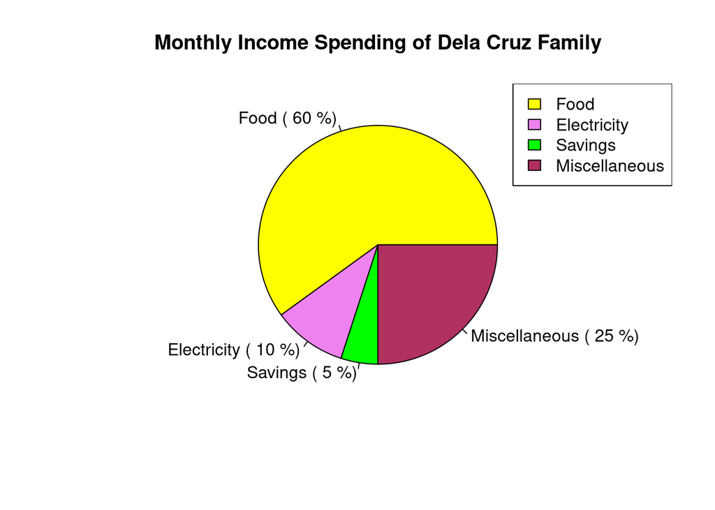

```r
spending_data <- data.frame(
  Category = c("Food", "Electricity", "Savings", "Miscellaneous"),
  Value = c(60, 10, 5, 25)
)

spending_data$Percentage <- spending_data$Value / sum(spending_data$Value) * 100

colors <- c("yellow", "violet", "green", "maroon")

pie(spending_data$Value,
    labels = paste(spending_data$Category,"(",spending_data$Percentage,"%)"),
    col = colors,
    main = "Monthly Income Spending of Dela Cruz Family")

legend("topright", spending_data$Category, fill = colors)
```

#6 Use the iris dataset.

```r
data(iris)
```

#6a Check for the structure of the dataset using the str() function. Describe what you have seen in the output.

```r
str(iris)
```

```
## 'data.frame':    150 obs. of  5 variables:
##  $ Sepal.Length: num  5.1 4.9 4.7 4.6 5 5.4 4.6 5 4.4 4.9 ...
##  $ Sepal.Width : num  3.5 3 3.2 3.1 3.6 3.9 3.4 3.4 2.9 3.1 ...
##  $ Petal.Length: num  1.4 1.4 1.3 1.5 1.4 1.7 1.4 1.5 1.4 1.5 ...
##  $ Petal.Width : num  0.2 0.2 0.2 0.2 0.2 0.4 0.3 0.2 0.2 0.1 ...
##  $ Species     : Factor w/ 3 levels "setosa","versicolor",..: 1 1 1 1 1 1 1 1 1 1 ...
```

```r
# The dataset is a collection of information about iris flowers. It has a collection of data of the length and width of the sepal and also the length and width of the petal for 150 different iris flowers. It also records the type of iris species to which each flower belongs. There are three species in the dataset: setosa, versicolor, and virginica.
```

#6b Create an R object that will contain the mean of the sepal.length,sepal.width,petal.length,and petal.width. What is the R script and its result?

```r
meanOfpetals <- colMeans(iris[,1:4])
meanOfpetals
```

```
## Sepal.Length  Sepal.Width Petal.Length  Petal.Width
##     5.843333     3.057333     3.758000     1.199333
```

#6c. Create a pie chart for the Species distribution. Add title, legends, and colors. Write the R script and its result.

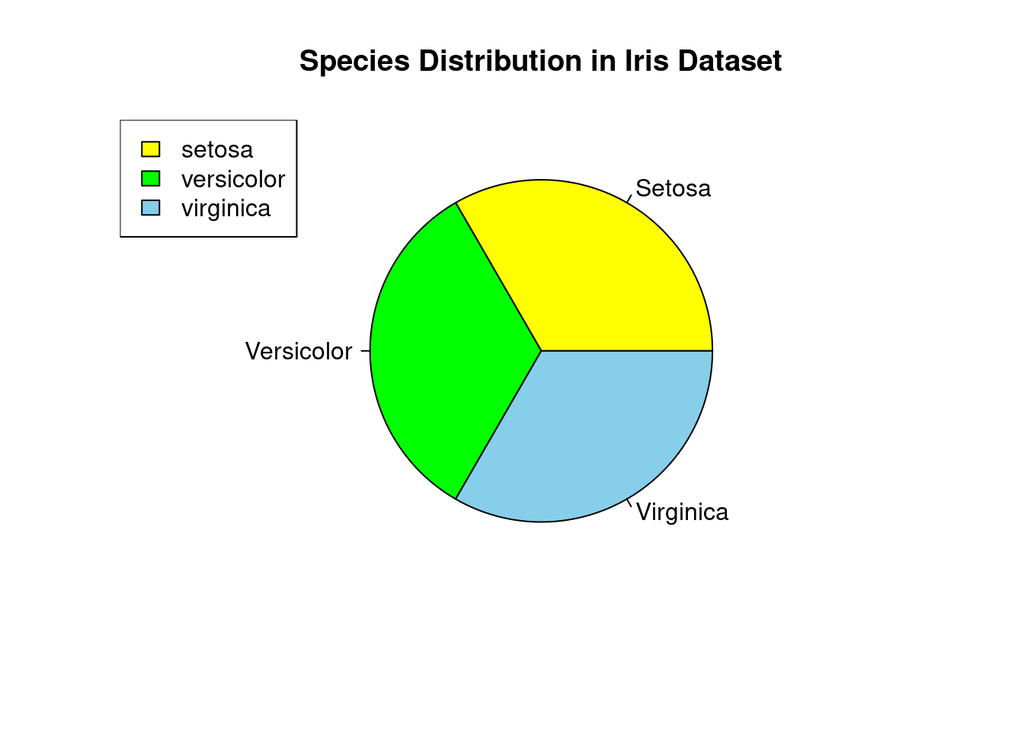

```r
species <- table(iris$Species)
nameOfSpecies <- c("Setosa", "Versicolor", "Virginica")

pie(species,
    labels = nameOfSpecies,
    col = c("yellow", "green", "skyblue"),
    main = "Species Distribution in Iris Dataset")

legend("topleft", legend = levels(iris$Species), fill = c("yellow", "green", "skyblue"),)
```

#6d Subset the species into setosa, versicolor, and virginica. Write the R scripts and show the last six (6) rows of each species.

```r
iris
```

| Sepal.Length | Sepal.Width | Petal.Length | Petal.Width | Species |
| --- | --- | --- | --- | --- |
| 5.1 | 3.5 | 1.4 | 0.2 | setosa |
| 4.9 | 3.0 | 1.4 | 0.2 | setosa |
| 4.7 | 3.2 | 1.3 | 0.2 | setosa |
| 4.6 | 3.1 | 1.5 | 0.2 | setosa |
| 5.0 | 3.6 | 1.4 | 0.2 | setosa |
| 5.4 | 3.9 | 1.7 | 0.4 | setosa |
| 4.6 | 3.4 | 1.4 | 0.3 | setosa |
| 5.0 | 3.4 | 1.5 | 0.2 | setosa |
| 4.4 | 2.9 | 1.4 | 0.2 | setosa |
| 4.9 | 3.1 | 1.5 | 0.1 | setosa |

[output cut: 140 more lines]

```r
subsetSetosa <- iris[iris$Species == "setosa",]
subsetSetosa
```

|  | Sepal.Length | Sepal.Width | Petal.Length | Petal.Width | Species |
| --- | --- | --- | --- | --- | --- |
| 1 | 5.1 | 3.5 | 1.4 | 0.2 | setosa |
| 2 | 4.9 | 3.0 | 1.4 | 0.2 | setosa |
| 3 | 4.7 | 3.2 | 1.3 | 0.2 | setosa |
| 4 | 4.6 | 3.1 | 1.5 | 0.2 | setosa |
| 5 | 5.0 | 3.6 | 1.4 | 0.2 | setosa |
| 6 | 5.4 | 3.9 | 1.7 | 0.4 | setosa |
| 7 | 4.6 | 3.4 | 1.4 | 0.3 | setosa |
| 8 | 5.0 | 3.4 | 1.5 | 0.2 | setosa |
| 9 | 4.4 | 2.9 | 1.4 | 0.2 | setosa |
| 10 | 4.9 | 3.1 | 1.5 | 0.1 | setosa |

[output cut: 40 more lines]

```r
subsetVersicolor <- iris[iris$Species == "versicolor",]
subsetVersicolor
```

|  | Sepal.Length | Sepal.Width | Petal.Length | Petal.Width | Species |
| --- | --- | --- | --- | --- | --- |
| 51 | 7.0 | 3.2 | 4.7 | 1.4 | versicolor |
| 52 | 6.4 | 3.2 | 4.5 | 1.5 | versicolor |
| 53 | 6.9 | 3.1 | 4.9 | 1.5 | versicolor |
| 54 | 5.5 | 2.3 | 4.0 | 1.3 | versicolor |
| 55 | 6.5 | 2.8 | 4.6 | 1.5 | versicolor |
| 56 | 5.7 | 2.8 | 4.5 | 1.3 | versicolor |
| 57 | 6.3 | 3.3 | 4.7 | 1.6 | versicolor |
| 58 | 4.9 | 2.4 | 3.3 | 1.0 | versicolor |
| 59 | 6.6 | 2.9 | 4.6 | 1.3 | versicolor |
| 60 | 5.2 | 2.7 | 3.9 | 1.4 | versicolor |

[output cut: 40 more lines]

```r
subsetVirginica <- iris[iris$Species == "virginica",]
subsetVirginica
```

|  | Sepal.Length | Sepal.Width | Petal.Length | Petal.Width | Species |
| --- | --- | --- | --- | --- | --- |
| 101 | 6.3 | 3.3 | 6.0 | 2.5 | virginica |
| 102 | 5.8 | 2.7 | 5.1 | 1.9 | virginica |
| 103 | 7.1 | 3.0 | 5.9 | 2.1 | virginica |
| 104 | 6.3 | 2.9 | 5.6 | 1.8 | virginica |
| 105 | 6.5 | 3.0 | 5.8 | 2.2 | virginica |
| 106 | 7.6 | 3.0 | 6.6 | 2.1 | virginica |
| 107 | 4.9 | 2.5 | 4.5 | 1.7 | virginica |
| 108 | 7.3 | 2.9 | 6.3 | 1.8 | virginica |
| 109 | 6.7 | 2.5 | 5.8 | 1.8 | virginica |
| 110 | 7.2 | 3.6 | 6.1 | 2.5 | virginica |

[output cut: 40 more lines]

```r
tail(subsetSetosa)
```

|  | Sepal.Length | Sepal.Width | Petal.Length | Petal.Width | Species |
| --- | --- | --- | --- | --- | --- |
| 45 | 5.1 | 3.8 | 1.9 | 0.4 | setosa |
| 46 | 4.8 | 3.0 | 1.4 | 0.3 | setosa |
| 47 | 5.1 | 3.8 | 1.6 | 0.2 | setosa |
| 48 | 4.6 | 3.2 | 1.4 | 0.2 | setosa |
| 49 | 5.3 | 3.7 | 1.5 | 0.2 | setosa |
| 50 | 5.0 | 3.3 | 1.4 | 0.2 | setosa |

```r
tail(subsetVersicolor)
```

|  | Sepal.Length | Sepal.Width | Petal.Length | Petal.Width | Species |
| --- | --- | --- | --- | --- | --- |
| 95 | 5.6 | 2.7 | 4.2 | 1.3 | versicolor |
| 96 | 5.7 | 3.0 | 4.2 | 1.2 | versicolor |
| 97 | 5.7 | 2.9 | 4.2 | 1.3 | versicolor |
| 98 | 6.2 | 2.9 | 4.3 | 1.3 | versicolor |
| 99 | 5.1 | 2.5 | 3.0 | 1.1 | versicolor |
| 100 | 5.7 | 2.8 | 4.1 | 1.3 | versicolor |

```r
tail(subsetVirginica)
```

|  | Sepal.Length | Sepal.Width | Petal.Length | Petal.Width | Species |
| --- | --- | --- | --- | --- | --- |
| 145 | 6.7 | 3.3 | 5.7 | 2.5 | virginica |
| 146 | 6.7 | 3.0 | 5.2 | 2.3 | virginica |
| 147 | 6.3 | 2.5 | 5.0 | 1.9 | virginica |
| 148 | 6.5 | 3.0 | 5.2 | 2.0 | virginica |
| 149 | 6.2 | 3.4 | 5.4 | 2.3 | virginica |
| 150 | 5.9 | 3.0 | 5.1 | 1.8 | virginica |

#6e Create a scatterplot of the sepal.length and sepal.width using the different species(setosa,versicolor,virginica). Add a title = “Iris Dataset”, subtitle = “Sepal width and length, labels for the x and y axis, the pch symbol and colors should be based onthe species.

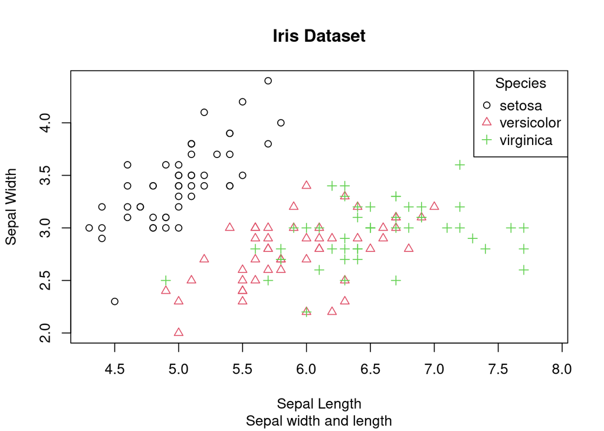

```r
plot(iris$Sepal.Length, iris$Sepal.Width,
     xlab = "Sepal Length", ylab = "Sepal Width",
     main = "Iris Dataset", sub = "Sepal width and length",
     pch = as.numeric(iris$Species), col = as.numeric(iris$Species))

legend("topright", legend = levels(iris$Species),
       pch = 1:3, col = 1:3,
       title = "Species")
```

#6f Interpret the result.

```r
#The scatterplot help us see how iris flowers of different species differ in terms of sepal length and width.

#The Setosa flowers typically have short sepal length and wide sepal width. They are grouped in the upper left part of the plot.

#Versicolor flowers have average sepal length and width. They are in the middle part.

#Virginica flowers are usually long in sepal length and have narrower sepal width. They form a group in the right part.

#Based on the plot, it is easy to see the differences between the three iris species based on sepal length and width.
```

#7 Import the alexa-file.xlsx. Check on the variations. Notice that there are ex-tra whitespaces among black variants (Black Dot, Black Plus, Black Show, BlackSpot). Also on the white variants (White Dot, White Plus, White Show, WhiteSpot).

```r
library(readxl)
alexa_file <- read_excel("alexa_file.xlsx")
```

#7a Rename the white and black variants by using gsub() function.

```r
alexa_file$variation <- gsub("Black  Dot", "BlackDot", alexa_file$variation)
alexa_file$variation <- gsub("Black  Plus", "BlackPlus", alexa_file$variation)
alexa_file$variation <- gsub("Black  Show", "BlackShow", alexa_file$variation)
alexa_file$variation <- gsub("Black  Spot", "BlackSpot", alexa_file$variation)

alexa_file$variation <- gsub("White  Dot", "WhiteDot", alexa_file$variation)
alexa_file$variation <- gsub("White  Plus", "WhitePlus", alexa_file$variation)
alexa_file$variation <- gsub("White  Show", "WhiteShow", alexa_file$variation)
alexa_file$variation <- gsub("White  Spot", "WhiteSpot", alexa_file$variation)
```

#7b Get the total number of each variations and save it into another object. Save the object as variations.RData. Write the R scripts. What is its result?

```r
install.packages("dplyr")
library("dplyr")
variations_total <- alexa_file %>%
  count(alexa_file$variation)

variations_total
```

| alexa_file$variation | n |
| --- | --- |
| Black | 261 |
| BlackDot | 516 |
| BlackPlus | 270 |
| BlackShow | 265 |
| BlackSpot | 241 |
| Charcoal Fabric | 430 |
| Configuration: Fire TV Stick | 350 |
| Heather Gray Fabric | 157 |
| Oak Finish | 14 |
| Sandstone Fabric | 90 |

[output cut: 6 more lines]

```r
save(variations_total, file = "variations.RData")
```

#7c From the variations.RData, create a barplot(). Complete the details of the chart which include the title, color, labels of each bar.

```r
load("variations.RData")
variations_total
```

| alexa_file$variation | n |
| --- | --- |
| Black | 261 |
| BlackDot | 516 |
| BlackPlus | 270 |
| BlackShow | 265 |
| BlackSpot | 241 |
| Charcoal Fabric | 430 |
| Configuration: Fire TV Stick | 350 |
| Heather Gray Fabric | 157 |
| Oak Finish | 14 |
| Sandstone Fabric | 90 |

[output cut: 6 more lines]

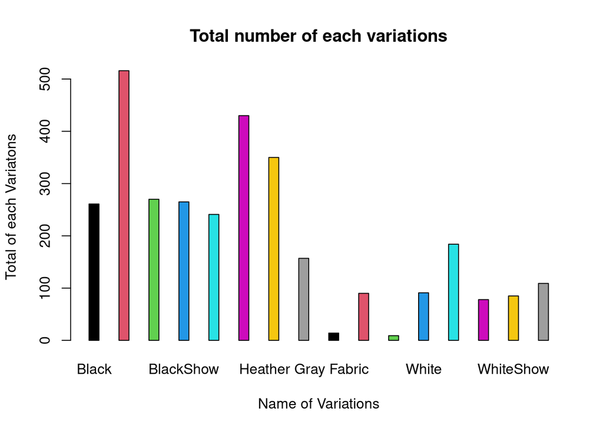

```r
varNames <- variations_total$`alexa_file$variation`

totalPlot <- barplot(variations_total$n,
        names.arg = varNames,
        main = "Total number of each variations",
        xlab = "Name of Variations",
        ylab = "Total of each Variatons",
        col = 1:16,
        space = 2)
```

#7d Create a barplot() for the black and white variations. Plot it in 1 frame, side by side. Complete the details of the chart.

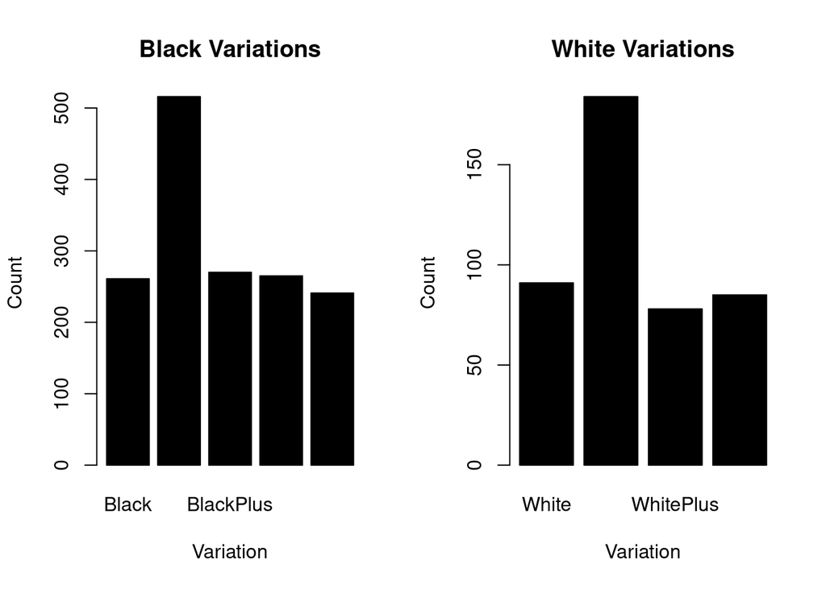

```r
blackVars <- variations_total[variations_total$`alexa_file$variation` %in% c("Black", "BlackPlus" , "BlackShow" ,"BlackSpot" , "BlackDot"), ]

whiteVars <- variations_total[variations_total$`alexa_file$variation` %in% c("White", "WhiteDot", "WhitePlus", "WhiteShow", " WhiteSpot"), ]

par(mfrow = c(1,2))

barplot(height = blackVars$n,
        names.arg = blackVars$`alexa_file$variation`,
        col = c("black"),
        main = "Black Variations",
        xlab = "Variation",
        ylab = "Count",
        border = "black")

barplot(height = whiteVars$n,
        names.arg = whiteVars$`alexa_file$variation`,
        col = c("black"),
        main = "White Variations",
        xlab = "Variation",
        ylab = "Count",
        border = "black")
```

```r
#1
    vectorA <-c (1,2,3,4,5)
    seroMatrix<- matrix(0,nrow=5, ncol=5)

    for (i in 1:5){
    for (j in 1:5){

    hat <- abs(vectorA[i]-j)

    cat(hat," ")
 }
    cat ("\n")
}
```

```
## 0  1  2  3  4
## 1  0  1  2  3
## 2  1  0  1  2
## 3  2  1  0  1
## 4  3  2  1  0
```

#2

```r
    for (i in 1:5){
    hat <- rep ("*",i)
    print(hat)
}
```

```
## [1] "*"
## [1] "*" "*"
## [1] "*" "*" "*"
## [1] "*" "*" "*" "*"
## [1] "*" "*" "*" "*" "*"
```

#3 Get an input from the user to print the Fibonacci sequence starting from the 1st input up to 500. Use repeat and break statements. Write the R Scripts and its output.

```r
   userInput <- as.integer(readline("Enter starting number for Fibonacci sequence: "))
```

```
## Enter starting number for Fibonacci sequence:
```

```r
a <- userInput
b <- 0


cat("Fibonacci sequence starting from", userInput, ":\n")
```

```
## Fibonacci sequence starting from NA :
```

```r
repeat {

  next_num <- a + b

  if (next_num > 500){
    break
  }
  cat(next_num, " ")
  a <- y
  b <- next_num
}
```

```
## Error in if (next_num > 500) {: missing value where TRUE/FALSE needed
```

#4a What is the R script for importing an excel or a csv file? Display the first 6 rows of the dataset? Show your codes and its result

```r
prevData <- read.csv("householdData.csv")
```

```
## Error in file(file, "rt"): cannot open the connection
```

```r
head(prevData)
```

```
## Error in eval(expr, envir, enclos): object 'prevData' not found
```

#4b Create a subset for gender(female and male). How many observations are there in Male? How about in Female? Write the R scripts and its output.

```r
Male <- Data[Data$Gender == "M",]
```

```
## Error in eval(expr, envir, enclos): object 'Data' not found
```

```r
Male
```

```
## Error in eval(expr, envir, enclos): object 'Male' not found
```

```r
Female <- Data[Data$Gender == "F",]
```

```
## Error in eval(expr, envir, enclos): object 'Data' not found
```

```r
Female
```

```
## Error in eval(expr, envir, enclos): object 'Female' not found
```

```r
numofMale <- nrow(Male)
```

```
## Error in eval(expr, envir, enclos): object 'Male' not found
```

```r
numofMale
```

```
## Error in eval(expr, envir, enclos): object 'numofMale' not found
```

```r
numofFem <- nrow(Female)
```

```
## Error in eval(expr, envir, enclos): object 'Female' not found
```

```r
numofFem
```

```
## Error in eval(expr, envir, enclos): object 'numofFem' not found
```

#4c Create a graph for the number of males and females for Household Data. Use plot(), chart type = barplot. Make sure to place title, legends, and colors. Write the R scripts and its result.

```r
totalMaleFemale <- table(prevData$Gender)
```

```
## Error in eval(expr, envir, enclos): object 'prevData' not found
```

```r
barplot(totalMaleFemale,
        main = "Number of Males and Females",
        xlab = "Gender",
        ylab = "Count",
        col = c("red", "blue"),
        legend.text = rownames(totalMaleFemale),
        beside = TRUE)
```

```
## Error in eval(expr, envir, enclos): object 'totalMaleFemale' not found
```

#5 The monthly income of Dela Cruz family was spent on the following: Food Electricity Savings Miscellaneous 60 10 5 25

#a Create a piechart that will include labels in percentage.Add some colors and title of the chart. Write the R scripts and show its output.

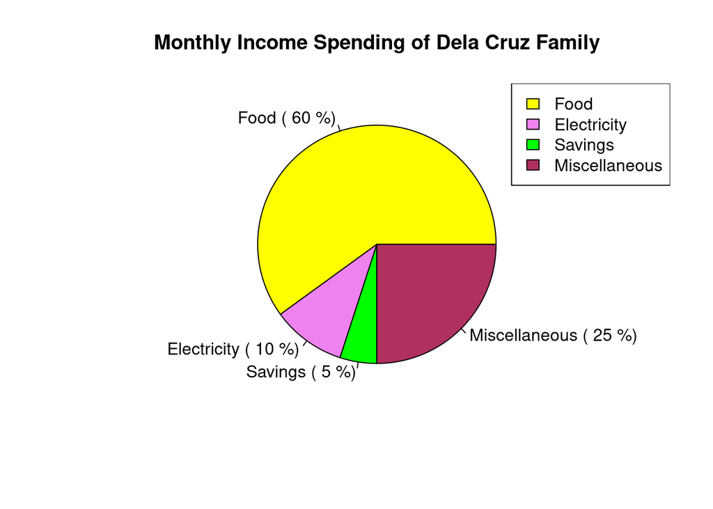

```r
spending_data <- data.frame(
  Category = c("Food", "Electricity", "Savings", "Miscellaneous"),
  Value = c(60, 10, 5, 25)
)

spending_data$Percentage <- spending_data$Value / sum(spending_data$Value) * 100

colors <- c("yellow", "violet", "green", "maroon")

pie(spending_data$Value,
    labels = paste(spending_data$Category,"(",spending_data$Percentage,"%)"),
    col = colors,
    main = "Monthly Income Spending of Dela Cruz Family")

legend("topright", spending_data$Category, fill = colors)
```

#6 Use the iris dataset.

```r
data(iris)
iris
```

| Sepal.Length | Sepal.Width | Petal.Length | Petal.Width | Species |
| --- | --- | --- | --- | --- |
| 5.1 | 3.5 | 1.4 | 0.2 | setosa |
| 4.9 | 3.0 | 1.4 | 0.2 | setosa |
| 4.7 | 3.2 | 1.3 | 0.2 | setosa |
| 4.6 | 3.1 | 1.5 | 0.2 | setosa |
| 5.0 | 3.6 | 1.4 | 0.2 | setosa |
| 5.4 | 3.9 | 1.7 | 0.4 | setosa |
| 4.6 | 3.4 | 1.4 | 0.3 | setosa |
| 5.0 | 3.4 | 1.5 | 0.2 | setosa |
| 4.4 | 2.9 | 1.4 | 0.2 | setosa |
| 4.9 | 3.1 | 1.5 | 0.1 | setosa |

[output cut: 140 more lines]

#6a Check for the structure of the dataset using the str() function. Describe what you have seen in the output.

```r
str(iris)
```

```
## 'data.frame':    150 obs. of  5 variables:
##  $ Sepal.Length: num  5.1 4.9 4.7 4.6 5 5.4 4.6 5 4.4 4.9 ...
##  $ Sepal.Width : num  3.5 3 3.2 3.1 3.6 3.9 3.4 3.4 2.9 3.1 ...
##  $ Petal.Length: num  1.4 1.4 1.3 1.5 1.4 1.7 1.4 1.5 1.4 1.5 ...
##  $ Petal.Width : num  0.2 0.2 0.2 0.2 0.2 0.4 0.3 0.2 0.2 0.1 ...
##  $ Species     : Factor w/ 3 levels "setosa","versicolor",..: 1 1 1 1 1 1 1 1 1 1 ...
```

```r
# The dataset is a collection of information about iris flowers. It has a collection of data of the length and width of the sepal and also the length and width of the petal for 150 different iris flowers. It also records the type of iris species to which each flower belongs. There are three species in the dataset: setosa, versicolor, and virginica.
```

#6b Create an R object that will contain the mean of the sepal.length,sepal.width,petal.length,and petal.width. What is the R script and its result?

```r
meanOfpetals <- colMeans(iris[,1:4])
meanOfpetals
```

```
## Sepal.Length  Sepal.Width Petal.Length  Petal.Width
##     5.843333     3.057333     3.758000     1.199333
```

#6c. Create a pie chart for the Species distribution. Add title, legends, and colors. Write the R script and its result.

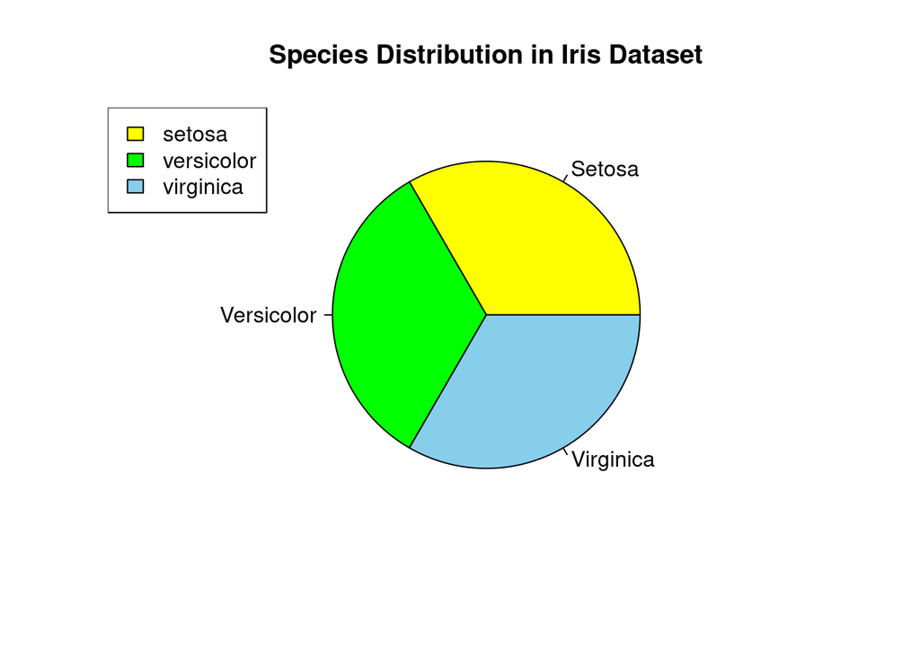

```r
species <- table(iris$Species)
nameOfSpecies <- c("Setosa", "Versicolor", "Virginica")

pie(species,
    labels = nameOfSpecies,
    col = c("yellow", "green", "skyblue"),
    main = "Species Distribution in Iris Dataset")

legend("topleft", legend = levels(iris$Species), fill = c("yellow", "green", "skyblue"),)
```

#6d Subset the species into setosa, versicolor, and virginica. Write the R scripts and show the last six (6) rows of each species.

[output not shown]

[figure not shown]

#6f Interpret the result.

```r
#The scatterplot help us see how iris flowers of different species differ in terms of sepal length and width.

#The Setosa flowers typically have short sepal length and wide sepal width. They are grouped in the upper left part of the plot.

#Versicolor flowers have average sepal length and width. They are in the middle part.

#Virginica flowers are usually long in sepal length and have narrower sepal width. They form a group in the right part.

#Based on the plot, it is easy to see the differences between the three iris species based on sepal length and width.
```

#7 Import the alexa-file.xlsx. Check on the variations. Notice that there are ex-tra whitespaces among black variants (Black Dot, Black Plus, Black Show, BlackSpot). Also on the white variants (White Dot, White Plus, White Show, WhiteSpot).

```r
library(readxl)
alexa_file <- read_excel("alexa_file.xlsx")
View(alexa_file)
```

```
## Error in .External2(C_dataviewer, x, title): unable to start data viewer
```

#7a Rename the white and black variants by using gsub() function.

```r
alexa_file$variation <- gsub("Black  Dot", "BlackDot", alexa_file$variation)
alexa_file$variation <- gsub("Black  Plus", "BlackPlus", alexa_file$variation)
alexa_file$variation <- gsub("Black  Show", "BlackShow", alexa_file$variation)
alexa_file$variation <- gsub("Black  Spot", "BlackSpot", alexa_file$variation)

alexa_file$variation <- gsub("White  Dot", "WhiteDot", alexa_file$variation)
alexa_file$variation <- gsub("White  Plus", "WhitePlus", alexa_file$variation)
alexa_file$variation <- gsub("White  Show", "WhiteShow", alexa_file$variation)
alexa_file$variation <- gsub("White  Spot", "WhiteSpot", alexa_file$variation)

View(alexa_file)
```

```
## Error in .External2(C_dataviewer, x, title): unable to start data viewer
```

#7b Get the total number of each variations and save it into another object. Save the object as variations.RData. Write the R scripts. What is its result?

```r
#install.packages("dplyr")
library("dplyr")

variations_total <- alexa_file %>%
  count(alexa_file$variation)

variations_total
```

| alexa_file$variation | n |
| --- | --- |
| Black | 261 |
| BlackDot | 516 |
| BlackPlus | 270 |
| BlackShow | 265 |
| BlackSpot | 241 |
| Charcoal Fabric | 430 |
| Configuration: Fire TV Stick | 350 |
| Heather Gray Fabric | 157 |
| Oak Finish | 14 |
| Sandstone Fabric | 90 |

[output cut: 6 more lines]

```r
save(variations_total, file = "variations.RData")
```

#7c From the variations.RData, create a barplot(). Complete the details of the chart which include the title, color, labels of each bar.

```r
load("variations.RData")
variations_total
```

| alexa_file$variation | n |
| --- | --- |
| Black | 261 |
| BlackDot | 516 |
| BlackPlus | 270 |
| BlackShow | 265 |
| BlackSpot | 241 |
| Charcoal Fabric | 430 |
| Configuration: Fire TV Stick | 350 |
| Heather Gray Fabric | 157 |
| Oak Finish | 14 |
| Sandstone Fabric | 90 |

[output cut: 6 more lines]

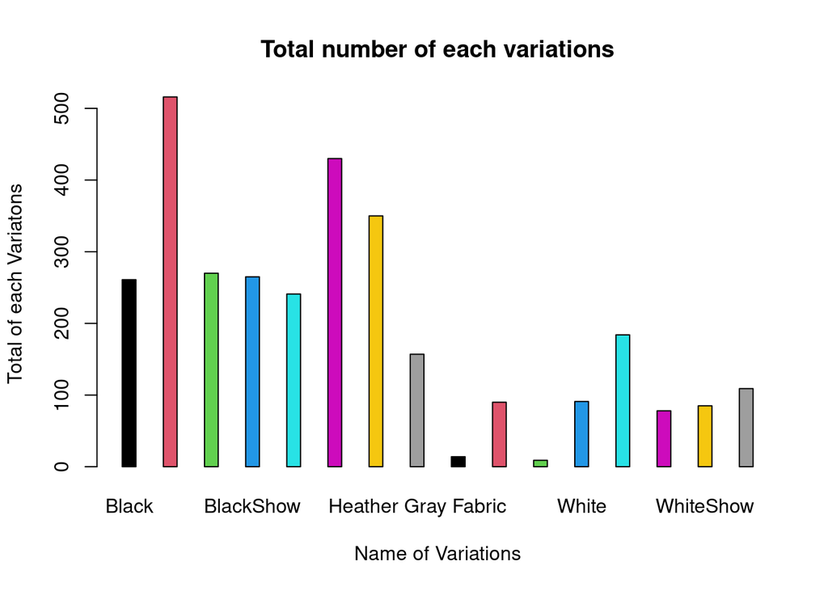

```r
varNames <- variations_total$`alexa_file$variation`

totalPlot <- barplot(variations_total$n,
        names.arg = varNames,
        main = "Total number of each variations",
        xlab = "Name of Variations",
        ylab = "Total of each Variatons",
        col = 1:16,
        space = 2)
```

#7d Create a barplot() for the black and white variations. Plot it in 1 frame, side by side. Complete the details of the chart.

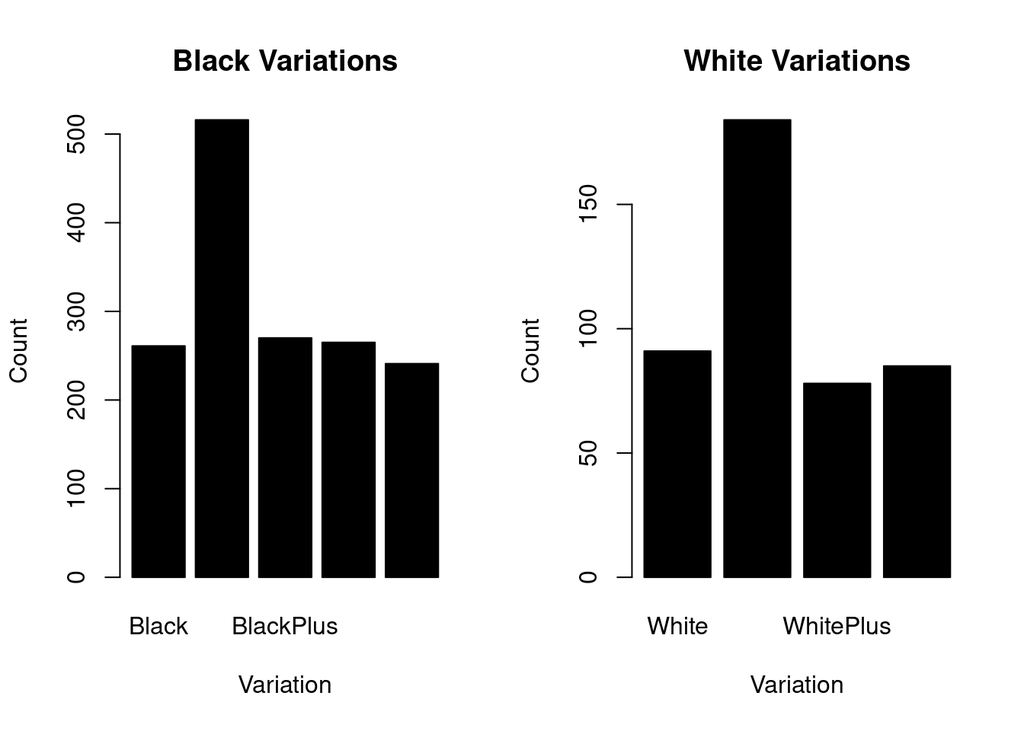

```r
blackVars <- variations_total[variations_total$`alexa_file$variation` %in% c("Black", "BlackPlus" , "BlackShow" ,"BlackSpot" , "BlackDot"), ]

whiteVars <- variations_total[variations_total$`alexa_file$variation` %in% c("White", "WhiteDot", "WhitePlus", "WhiteShow", " WhiteSpot"), ]

par(mfrow = c(1,2))

barplot(height = blackVars$n,
        names.arg = blackVars$`alexa_file$variation`,
        col = c("black"),
        main = "Black Variations",
        xlab = "Variation",
        ylab = "Count",
        border = "black")

barplot(height = whiteVars$n,
        names.arg = whiteVars$`alexa_file$variation`,
        col = c("black"),
        main = "White Variations",
        xlab = "Variation",
        ylab = "Count",
        border = "black")
```